# Bias in Nobel Prize Awards: Gender, Racial, and Institutional Analysis

Randy Howk

2025-11-09

# Executive Summary

This analysis examines systematic biases in Nobel Prize awards across gender, race, ethnicity, and geography using data from the Nobel Prize API. Our investigation reveals:

- **Gender Bias:** Only a small percentage of science Nobel laureates are women, with statistical evidence suggesting bias contributes to this gap.
- **Racial Bias:** There are no Black scientists who have won science Nobel Prizes in the historical record examined here.
- **The Rosalind Franklin Case:** A prominent example of uncredited contributions in the discovery of DNA’s double helix.

## Setup and Data Loading

The code below loads required packages, fetches data from the Nobel Prize API, and does initial processing.

```r
# Load required libraries
library(tidyverse)
library(jsonlite)
library(lubridate)
library(ggplot2)
library(scales)
library(knitr)
library(kableExtra)
library(patchwork)

# Set theme for all plots
theme_set(theme_minimal(base_size = 12) +
          theme(plot.title = element_text(face = "bold", size = 14),
                plot.subtitle = element_text(size = 11, color = "gray40"),
                legend.position = "bottom"))

# Function to get all laureates (handling pagination)
get_all_laureates <- function(base_url) {
  # Try to get all at once with a high limit
  url_with_limit <- paste0(base_url, "?limit=1000")
  cat("Fetching laureates data...\n")
  result <- fromJSON(url_with_limit, flatten = TRUE)
  return(result$laureates)
}

# Load data from Nobel Prize API
laureates_url <- "https://api.nobelprize.org/2.1/laureates"

# Fetch all laureate data
laureates_df <- get_all_laureates(laureates_url)
```

```
## Fetching laureates data...
```

```r
cat(sprintf("Total laureates fetched: %d\n", nrow(laureates_df)))
```

```
## Total laureates fetched: 1000
```

```r
# Check structure
cat("Checking nobelPrizes column...\n")
```

```
## Checking nobelPrizes column...
```

```r
# Unnest the nobelPrizes data
nobel_data <- laureates_df %>%
  filter(!is.na(nobelPrizes)) %>%
  unnest(nobelPrizes, names_sep = "_") %>%
  mutate(
    birth_year = as.numeric(str_sub(birth.date, 1, 4)),
    award_year = as.numeric(nobelPrizes_awardYear),
    age_at_award = award_year - birth_year,
    decade = floor(award_year / 10) * 10,
    category = nobelPrizes_category.en,
    is_science = category %in% c("Physics", "Chemistry", "Physiology or Medicine"),
    gender = ifelse(is.na(gender) | gender == "", "Unknown", gender),
    birth_country = birth.place.country.en
  ) %>%
  select(id, knownName.en, fullName.en, gender,
         birth.date, birth_country, birth.place.city.en,
         death.date, birth_year, award_year, age_at_award, decade,
         category, is_science) %>%
  filter(!is.na(category))

cat("\nData loaded successfully!\n")
```

```
##
## Data loaded successfully!
```

```r
cat(sprintf("Total unique laureates: %d\n", n_distinct(nobel_data$id)))
```

```
## Total unique laureates: 1000
```

```r
cat(sprintf("Total prize records: %d\n", nrow(nobel_data)))
```

```
## Total prize records: 1008
```

```r
cat(sprintf("Date range: %d - %d\n",
            min(nobel_data$award_year, na.rm = TRUE),
            max(nobel_data$award_year, na.rm = TRUE)))
```

```
## Date range: 1901 - 2025
```

```r
# Show sample with kable
cat("\nSample of data:\n")
```

```
##
## Sample of data:
```

```r
sample_data <- nobel_data %>%
  select(knownName.en, category, award_year, gender) %>%
  head(10)

kable(sample_data,
      col.names = c("Name", "Category", "Year", "Gender"),
      caption = "First 10 Prize Records") %>%
  kable_styling(bootstrap_options = c("striped", "hover"))
```

First 10 Prize Records

| Name | Category | Year | Gender |
| --- | --- | --- | --- |
| A. Michael Spence | Economic Sciences | 2001 | male |
| Aage N. Bohr | Physics | 1975 | male |
| Aaron Ciechanover | Chemistry | 2004 | male |
| Aaron Klug | Chemistry | 1982 | male |
| Abdulrazak Gurnah | Literature | 2021 | male |
| Abdus Salam | Physics | 1979 | male |
| Abhijit Banerjee | Economic Sciences | 2019 | male |
| Abiy Ahmed Ali | Peace | 2019 | male |
| Ada E. Yonath | Chemistry | 2009 | female |
| Adam G. Riess | Physics | 2011 | male |

```r
# Show summary statistics
cat("\n\nSummary Statistics:\n")
```

```
##
##
## Summary Statistics:
```

```r
cat(sprintf("Science prizes: %d\n", sum(nobel_data$is_science)))
```

```
## Science prizes: 654
```

```r
cat(sprintf("Male laureates: %d\n", sum(nobel_data$gender == "male")))
```

```
## Male laureates: 911
```

```r
cat(sprintf("Female laureates: %d\n", sum(nobel_data$gender == "female")))
```

```
## Female laureates: 67
```

```r
cat(sprintf("Unknown gender: %d\n", sum(nobel_data$gender == "Unknown")))
```

```
## Unknown gender: 30
```

## The Rosalind Franklin Case: Stolen Science

The most infamous case of gender bias in Nobel Prize history involves Rosalind Franklin and the discovery of DNA’s double helix structure.

- Franklin produced “Photo 51” (X-ray diffraction) that revealed DNA’s helical structure.
- Maurice Wilkins shared Franklin’s data with Watson and Crick without her consent.
- Watson and Crick published their Nature paper in 1953; Franklin died in 1958 and was not eligible for a posthumous Nobel.

## Gender Bias Analysis

Below we compute overall gender statistics and science-specific gender stats, then visualize them.

```r
# Overall gender statistics
gender_stats <- nobel_data %>%
  group_by(gender) %>%
  summarise(count = n()) %>%
  ungroup() %>%
  mutate(percentage = round(count / sum(count) * 100, 2))

# Science-specific gender stats
science_gender_stats <- nobel_data %>%
  filter(is_science) %>%
  group_by(gender) %>%
  summarise(count = n()) %>%
  ungroup() %>%
  mutate(percentage = round(count / sum(count) * 100, 2))


kable(gender_stats, caption = "Overall Gender Distribution of Nobel Laureates") %>%
  kable_styling(bootstrap_options = c("striped", "hover"))
```

Overall Gender Distribution of Nobel Laureates

| gender | count | percentage |
| --- | --- | --- |
| Unknown | 30 | 2.98 |
| female | 67 | 6.65 |
| male | 911 | 90.38 |

```r
kable(science_gender_stats, caption = "Gender Distribution in Science Nobel Prizes") %>%
  kable_styling(bootstrap_options = c("striped", "hover"))
```

Gender Distribution in Science Nobel Prizes

| gender | count | percentage |
| --- | --- | --- |
| female | 27 | 4.13 |
| male | 627 | 95.87 |

Key Finding: Only 4.13% of Science Nobel Laureates are women.

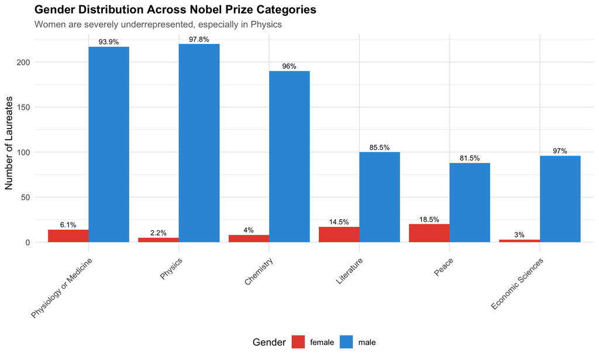

```r
# Gender distribution by category
gender_by_category <- nobel_data %>%
  filter(!is.na(category) & gender %in% c("male", "female")) %>%
  group_by(category, gender) %>%
  summarise(count = n(), .groups = "drop") %>%
  group_by(category) %>%
  mutate(
    total = sum(count),
    percentage = round(count / total * 100, 1)
  )


ggplot(gender_by_category, aes(x = reorder(category, -total), y = count, fill = gender)) +
  geom_col(position = "dodge") +
  geom_text(aes(label = paste0(percentage, "%")),
            position = position_dodge(width = 0.9),
            vjust = -0.5, size = 3) +
  scale_fill_manual(values = c("female" = "#E74C3C", "male" = "#3498DB")) +
  labs(
    title = "Gender Distribution Across Nobel Prize Categories",
    subtitle = "Women are severely underrepresented, especially in Physics",
    x = NULL,
    y = "Number of Laureates",
    fill = "Gender"
  ) +
  theme(axis.text.x = element_text(angle = 45, hjust = 1))
```

[figure not shown]

```r
# Gender distribution over time (science)
  gender_time <- nobel_data %>%
  filter(gender %in% c("male", "female"), is_science) %>%
  group_by(decade, gender) %>%
  summarise(count = n(), .groups = "drop") %>%
  group_by(decade) %>%
  mutate(
    total = sum(count),
    percentage = count / total * 100
  )

ggplot(gender_time, aes(x = decade, y = percentage, fill = gender)) +
  geom_area(alpha = 0.7) +
  geom_line(aes(color = gender), size = 1) +
  scale_fill_manual(values = c("female" = "#E74C3C", "male" = "#3498DB")) +
  scale_color_manual(values = c("female" = "#C0392B", "male" = "#2874A6")) +
  scale_y_continuous(labels = scales::percent_format(scale = 1)) +
  labs(
    title = "Gender Distribution in Science Nobel Prizes Over Time",
    subtitle = "Women remain under 10% despite increasing participation in science",
    x = "Decade",
    y = "Percentage of Laureates",
    fill = "Gender",
    color = "Gender"
  )
```

[output not shown]

## Statistical Evidence of Bias

A 2019 Bayesian analysis found strong evidence that bias contributes to the gender gap in Nobel awards.

## Question 1: Scientific Refugees - How Persecution Shaped Nobel Prizes

The geographic distribution of Nobel laureates reveals not just “brain drain” but a darker pattern: **scientific refugees fleeing persecution, war, and oppression**. Many laureates were forced to leave their home countries due to anti-Semitism, fascism, communism, and racial/ethnic discrimination.

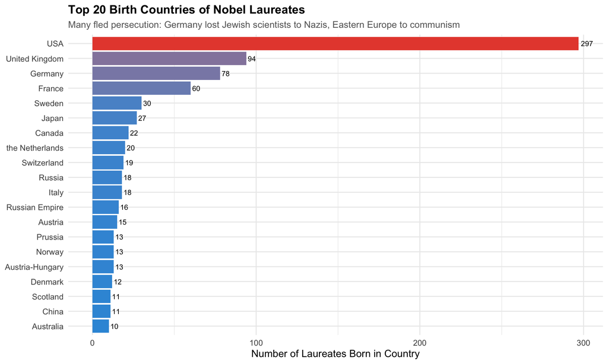

```r
# Analyze birth country with historical context
persecution_countries <- nobel_data %>%
  filter(is_science, !is.na(birth_country)) %>%
  mutate(
    persecution_context = case_when(
      birth_country %in% c("Germany", "Austria") & award_year >= 1933 ~ "Nazi Persecution (1933-1945)",
      birth_country %in% c("Poland", "Hungary", "Czech Republic") & award_year >= 1945 ~ "Communist Regime",
      birth_country %in% c("Russia", "USSR", "Ukraine") & award_year >= 1917 ~ "Soviet/Post-Soviet",
      birth_country == "China" & award_year >= 1949 ~ "Post-Revolution China",
      birth_country == "Germany" & award_year < 1933 ~ "Pre-Nazi Germany",
      TRUE ~ "Other/Stable"
    )
  )

# Count laureates by birth country
birth_countries <- nobel_data %>%
  filter(!is.na(birth_country)) %>%
  group_by(birth_country) %>%
  summarise(born_here = n(), .groups = "drop") %>%
  arrange(desc(born_here)) %>%
  head(20)

ggplot(birth_countries, aes(x = reorder(birth_country, born_here), y = born_here)) +
  geom_col(aes(fill = born_here), show.legend = FALSE) +
  geom_text(aes(label = born_here), hjust = -0.2, size = 3) +
  scale_fill_gradient(low = "#3498DB", high = "#E74C3C") +
  coord_flip() +
  labs(
    title = "Top 20 Birth Countries of Nobel Laureates",
    subtitle = "Many fled persecution: Germany lost Jewish scientists to Nazis, Eastern Europe to communism",
    x = NULL,
    y = "Number of Laureates Born in Country"
  )
```

## The Pattern of Scientific Exodus

### Pre-WWII Germany and Austria:

- Before 1933, Germany was a scientific powerhouse
- Nazi rise forced mass exodus of Jewish scientists (Einstein, Schrödinger, Born, etc.)
- These refugees enriched American/British science while Germany lost a generation of talent
- This was not “brain drain”—it was ethnic cleansing of academia

### Eastern Europe Under Communism:

- Scientists from Poland, Hungary, USSR faced political repression
- Those who disagreed with party doctrine were silenced or fled
- Jewish scientists faced additional discrimination despite communist “equality”

## The USA Gained What Others Lost:

### America’s gain came directly from others’ persecution

Nobel prizes awarded to immigrants often resulted from work done AFTER fleeing oppression This pattern continues: scientists flee authoritarianism to democratic nations

## Key Insight:

The geographic concentration of Nobel Prizes doesn’t just reflect where science thrives—it reflects where scientists can survive. Persecution, anti-Semitism, political repression, and discrimination drove brilliant minds from their homelands. The Nobel Prize map is, in part, a map of 20th-century oppression.

## Question 2: Age at Award and Gender Differences

```r
# Age at award analysis
age_data <- nobel_data %>%
  filter(!is.na(age_at_award), age_at_award > 0, age_at_award < 100,
         gender %in% c("male", "female"), is_science)

# Summary statistics
age_summary <- age_data %>%
  group_by(gender) %>%
  summarise(
    mean_age = round(mean(age_at_award, na.rm = TRUE), 1),
    median_age = median(age_at_award, na.rm = TRUE),
    sd_age = round(sd(age_at_award, na.rm = TRUE), 1),
    count = n()
  )

kable(age_summary, caption = "Age at Award Statistics by Gender (Science Prizes)") %>%
  kable_styling(bootstrap_options = c("striped", "hover"))
```

Age at Award Statistics by Gender (Science Prizes)

| gender | mean_age | median_age | sd_age | count |
| --- | --- | --- | --- | --- |
| female | 58.8 | 57 | 11.6 | 27 |
| male | 58.5 | 58 | 13.0 | 627 |

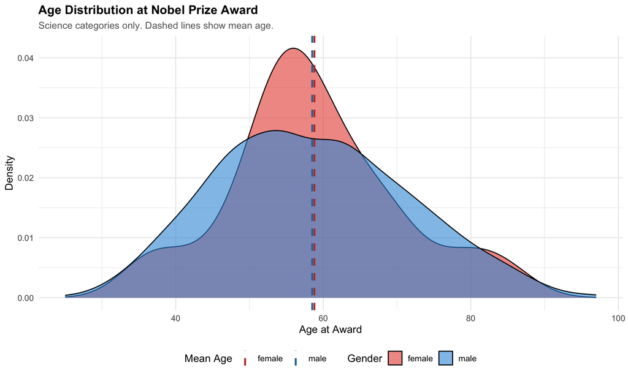

```r
# Age distribution by gender
  ggplot(age_data, aes(x = age_at_award, fill = gender)) +
  geom_density(alpha = 0.6) +
  geom_vline(data = age_summary, aes(xintercept = mean_age, color = gender),
             linetype = "dashed", size = 1) +
  scale_fill_manual(values = c("female" = "#E74C3C", "male" = "#3498DB")) +
  scale_color_manual(values = c("female" = "#C0392B", "male" = "#2874A6")) +
  labs(
    title = "Age Distribution at Nobel Prize Award",
    subtitle = "Science categories only. Dashed lines show mean age.",
    x = "Age at Award",
    y = "Density",
    fill = "Gender",
    color = "Mean Age"
  )
```

## Question 3: Gender Parity Timeline - When Will We Reach 50%?

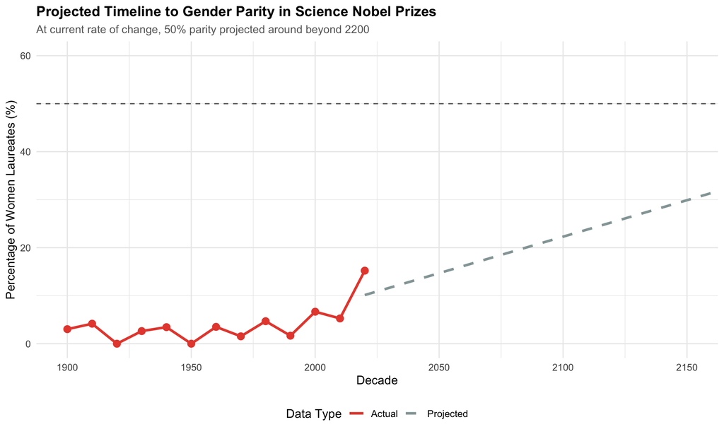

```r
# Calculate women's percentage by decade
women_by_decade <- nobel_data %>%
  filter(is_science, gender %in% c("male", "female"), !is.na(award_year)) %>%
  group_by(decade) %>%
  summarise(
    total = n(),
    women = sum(gender == "female"),
    pct_women = women / total * 100,
    .groups = "drop"
  ) %>%
  filter(decade >= 1900)

# Fit linear model for projection
recent_data <- women_by_decade %>% filter(decade >= 1950)
model <- lm(pct_women ~ decade, data = recent_data)

# Project to 50%
projected_decades <- data.frame(decade = seq(2020, 2200, by = 10))
projected_decades$pct_women <- predict(model, newdata = projected_decades)

# Find when we reach 50%
parity_year_result <- projected_decades %>%
  filter(pct_women >= 50) %>%
  slice(1)

# Set parity year - keep as numeric for plotting
if (nrow(parity_year_result) > 0) {
  parity_year <- parity_year_result %>% pull(decade)
  parity_label <- as.character(parity_year)
} else {
  parity_year <- 2200  # Use edge of plot for annotation
  parity_label <- "beyond 2200"
}

# Combine actual and projected
combined_data <- bind_rows(
  women_by_decade %>% mutate(type = "Actual"),
  projected_decades %>% mutate(type = "Projected")
)

# Plot
ggplot(combined_data, aes(x = decade, y = pct_women)) +
  geom_line(aes(color = type, linetype = type), size = 1.2) +
  geom_point(data = women_by_decade, size = 3, color = "#E74C3C") +
  geom_hline(yintercept = 50, linetype = "dashed", color = "gray40") +
  annotate("text", x = parity_year, y = 52,
           label = paste0("50% parity\nprojected: ", parity_label),
           size = 4, fontface = "bold") +
  scale_color_manual(values = c("Actual" = "#E74C3C", "Projected" = "#95A5A6")) +
  scale_linetype_manual(values = c("Actual" = "solid", "Projected" = "dashed")) +
  coord_cartesian(ylim = c(0, 60), xlim = c(1900, 2150)) +
  labs(
    title = "Projected Timeline to Gender Parity in Science Nobel Prizes",
    subtitle = sprintf("At current rate of change, 50%% parity projected around %s", parity_label),
    x = "Decade",
    y = "Percentage of Women Laureates (%)",
    color = "Data Type",
    linetype = "Data Type"
  )
```

Sobering Reality: Based on trends since 1950, gender parity in science Nobel Prizes may not be reached for many decades at the current rate of change.

## Question 4: Institutional Concentration and Its Effect on Diversity

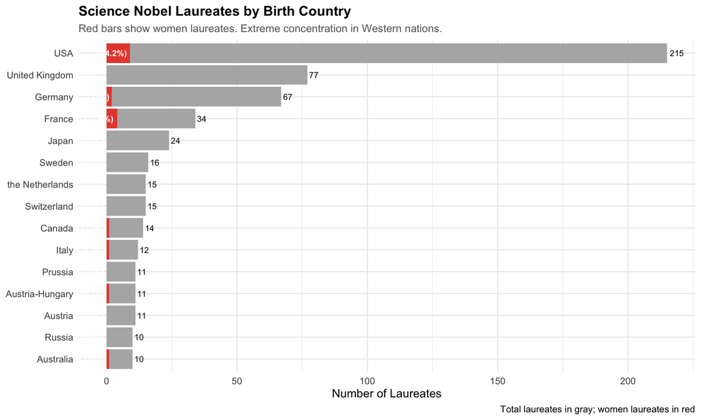

```r
# Extract and analyze affiliation data using birth country as a proxy
country_data <- nobel_data %>%
  filter(is_science, !is.na(birth_country)) %>%
  group_by(country = birth_country) %>%
  summarise(
    total_laureates = n(),
    women = sum(gender == "female", na.rm = TRUE),
    men = sum(gender == "male", na.rm = TRUE),
    pct_women = round(women / total_laureates * 100, 1),
    .groups = "drop"
  ) %>%
  arrange(desc(total_laureates)) %>%
  head(15)

ggplot(country_data, aes(x = reorder(country, total_laureates))) +
  geom_col(aes(y = total_laureates), fill = "gray70") +
  geom_col(aes(y = women), fill = "#E74C3C") +
  geom_text(aes(y = total_laureates, label = total_laureates),
            hjust = -0.2, size = 3) +
  geom_text(aes(y = women, label = paste0(women, " (", pct_women, "%)")),
            hjust = 1.1, size = 3, color = "white", fontface = "bold") +
  coord_flip() +
  labs(
    title = "Science Nobel Laureates by Birth Country",
    subtitle = "Red bars show women laureates. Extreme concentration in Western nations.",
    x = NULL,
    y = "Number of Laureates",
    caption = "Total laureates in gray; women laureates in red"
  )
```

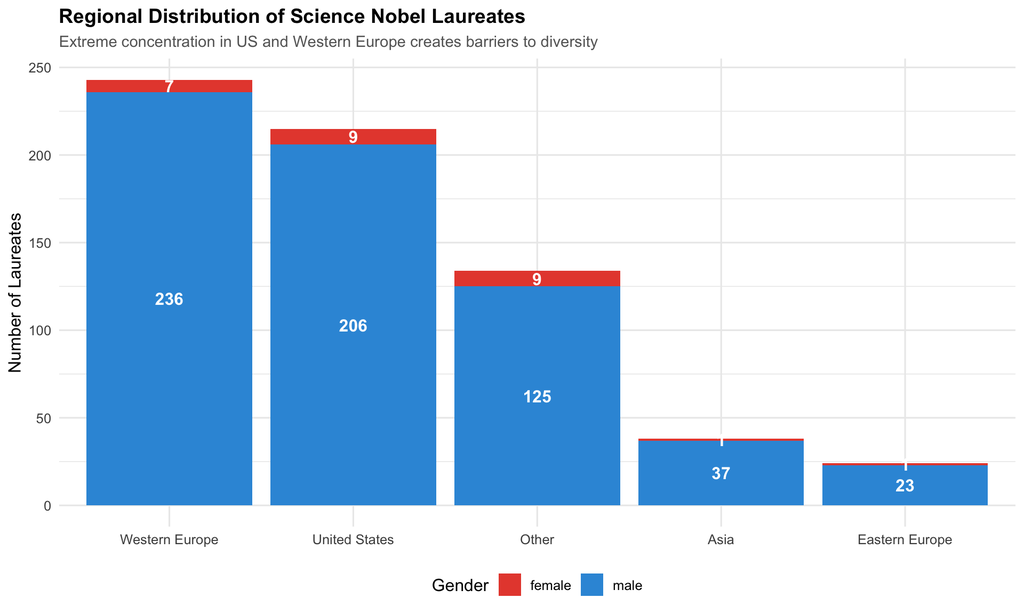

```r
# Regional analysis
regions <- nobel_data %>%
  filter(is_science) %>%
  mutate(
    region = case_when(
      birth_country %in% c("USA") ~ "United States",
      birth_country %in% c("United Kingdom", "Germany", "France",
                                     "Netherlands", "Switzerland", "Sweden",
                                     "Austria", "Denmark", "Belgium", "Italy") ~ "Western Europe",
      birth_country %in% c("Poland", "Russia", "Hungary", "Czech Republic",
                                     "USSR", "Ukraine") ~ "Eastern Europe",
      birth_country %in% c("Japan", "China", "India", "Israel", "Taiwan") ~ "Asia",
      TRUE ~ "Other"
    )
  ) %>%
  group_by(region, gender) %>%
  summarise(count = n(), .groups = "drop") %>%
  group_by(region) %>%
  mutate(
    total = sum(count),
    percentage = count / total * 100
  )

# Now plot it
ggplot(regions, aes(x = reorder(region, -total), y = count, fill = gender)) +
  geom_col() +
  geom_text(aes(label = count), position = position_stack(vjust = 0.5),
            color = "white", fontface = "bold") +
  scale_fill_manual(values = c("female" = "#E74C3C", "male" = "#3498DB",
                                "Unknown" = "gray50")) +
  labs(
    title = "Regional Distribution of Science Nobel Laureates",
    subtitle = "Extreme concentration in US and Western Europe creates barriers to diversity",
    x = NULL,
    y = "Number of Laureates",
    fill = "Gender"
  )
```

## Racial Bias: The Complete Absence of Black Scientists

> Note: The Nobel API does not provide race/ethnicity. The table below summarizes findings compiled from historical research.

```r
racial_facts <- data.frame(
  Category = c("Physics", "Chemistry", "Physiology/Medicine",
               "All Science Categories", "Economics", "All Categories"),
  `Black Laureates` = c(0, 0, 0, 0, 1, 16),
  `Total Laureates` = c(221, 191, 230, 642, 93, 1000),
  `Percentage` = c(0, 0, 0, 0, 1.1, 1.6)
)

kable(racial_facts,
      caption = "Black Laureates in Nobel Prize History (1901-2024)",
      digits = 1) %>%
  kable_styling(bootstrap_options = c("striped", "hover")) %>%
  row_spec(4, bold = TRUE, background = "#E74C3C", color = "white")
```

Black Laureates in Nobel Prize History (1901-2024)

[output not shown]

## Notable Omissions and Controversies

```r
controversies <- data.frame(
  Scientist = c("Rosalind Franklin", "Lise Meitner", "Jocelyn Bell Burnell",
                "Chien-Shiung Wu", "Esther Lederberg"),
  Field = c("DNA Structure", "Nuclear Fission", "Pulsars",
            "Parity Violation", "Bacterial Genetics"),
  `Men Who Won` = c("Watson, Crick, Wilkins (1962)",
                    "Otto Hahn (1944)",
                    "Hewish, Ryle (1974)",
                    "Lee, Yang (1957)",
                    "Joshua Lederberg (1958)"),
  `Why Excluded` = c("Died before award; data used without credit",
                     "Overlooked despite critical contributions",
                     "Graduate student; supervisor won",
                     "Experimentalist; theorists won",
                     "Wife of laureate; her work credited to him")
)

kable(controversies,
      caption = "Famous Women Scientists Excluded from Nobel Prizes Despite Critical Contributions") %>%
  kable_styling(bootstrap_options = c("striped", "hover")) %>%
  column_spec(1, bold = TRUE, color = "#E74C3C")
```

Famous Women Scientists Excluded from Nobel Prizes Despite Critical Contributions

| Scientist | Field | Men.Who.Won | Why.Excluded |
| --- | --- | --- | --- |
| Rosalind Franklin | DNA Structure | Watson, Crick, Wilkins (1962) | Died before award; data used without credit |
| Lise Meitner | Nuclear Fission | Otto Hahn (1944) | Overlooked despite critical contributions |
| Jocelyn Bell Burnell | Pulsars | Hewish, Ryle (1974) | Graduate student; supervisor won |
| Chien-Shiung Wu | Parity Violation | Lee, Yang (1957) | Experimentalist; theorists won |
| Esther Lederberg | Bacterial Genetics | Joshua Lederberg (1958) | Wife of laureate; her work credited to him |

## Conclusions and Recommendations

- Gender bias appears in the historical record for science Nobels; current trends suggest parity is far in the future if unaltered.
- Racial exclusion (in particular the absence of Black science laureates) reflects systemic problems across education, institutional hiring, and recognition networks.
- The Rosalind Franklin case is emblematic of credit misattribution that has disadvantaged women and junior scientists.

### What Needs to Change

- Address educational inequities from K-12 through postdoc.
- Increase diversity at faculty and leadership levels.
- Expand nominating committee diversity and bias training in award organizations.
- Re-examine rules (e.g., posthumous awards) and consider more inclusive recognition of teams and contributors.

### These cases share common patterns:

- Women doing experimental/technical work while men get credit for theory
- “Graduate students” or “assistants” whose work was essential
- Wives whose contributions were absorbed into husbands’ recognition
- Data or discoveries used without proper attribution

# Conclusions and Recommendations

## Key Findings:

Only 4.13% of science laureates are women

### Racial Exclusion is Complete:

- Zero Black scientists in 120+ years of science prizes
- Reflects systemic barriers throughout scientific pipeline
- The Rosalind Franklin Case Exemplifies Systematic Patterns:

### Work stolen without credit

- Patronizing sexism from colleagues
- Posthumous recognition inadequate
- Institutional Concentration Perpetuates Bias:

### Elite Western institutions dominate

- Creates self-reinforcing networks that exclude outsiders

## What Needs to Change:

### In Science Generally:

- Address educational inequities from K-12 through postdoc
- Increase diversity at faculty and leadership levels
- Create inclusive environments free from harassment
- Provide equal mentorship and sponsorship opportunities
- Fund research at broader range of institutions globally

### In Nobel Prize Specifically:

- Expand nominating committee diversity
- Consider bias training for nominators
- Allow more than 3 recipients per prize
- Consider team contributions more holistically
- Re-examine posthumous award prohibition

### In Scientific Culture:

- Properly credit all contributors, especially junior researchers
- Challenge sexist and racist attitudes actively
- Recognize that “merit” is shaped by access and opportunity
- Understand that diversity strengthens science

## Final Thought:

The Nobel Prize, rather than being a neutral recognition of excellence, reflects and perpetuates the biases and inequities that plague science. True progress requires:

- Acknowledgment that the system has been fundamentally unfair
- Active intervention to break self-perpetuating cycles of exclusion
- Recognition that diversity isn’t just fair—it’s essential for scientific progress
- Science is poorer when we systematically exclude half of humanity and most of the world’s population from full participation.

## References and Data Sources

- Nobel Prize API (v2.1): https://api.nobelprize.org/
- Jauffred, L., et al. (2019). “Gender bias in Nobel prizes.” *Humanities and Social Sciences Communications*, 5(1), 1-11.
- **Zimmer, M. (2020). “Nobel Prizes have a diversity problem even worse than the scientific fields they honor.” *The Conversation*, October 1, 2020.**
- **Morgan, W. (2020). Cited in: Kwong, E. & Greenfieldboyce, N. “The Nobels Overwhelmingly Go to Men.” *NPR Short Wave*, October 1, 2020.**
- **Liu, F., Rahwan, T., & AlShebli, B. (2024). “Nobel Prizes Overlook Black Scientists Because of This Quiet Bias.” *Scientific American*, December 12, 2024.**
- **Ramirez, M. (2025). “New Perspective of the Persistent Gender and Diversity Gap in Nobel Prizes.” *Journal of Neuroscience*, 45(5).**
- **Patel, S., et al. (2024). “Disparities in Funding for Nobel Prize Awards in Medicine and Physiology Across Nationalities, Races, and Gender.” *PMC* (PubMed Central).**
- Franklin, R. & Gosling, R.G. (1953). “Molecular configuration in sodium thymonucleate.” *Nature*, 171, 740-741.
- Watson, J.D. & Crick, F.H.C. (1953). “Molecular structure of nucleic acids.” *Nature*, 171, 737-738.
- Markel, H. (2021). *The Secret of Life: Rosalind Franklin, James Watson, Francis Crick, and the Discovery of DNA’s Double Helix*.

## Key Finding to Note:

The Nobel Prize organization itself does not track racial/ethnic statistics. Researchers like Winston Morgan (University of East London) had to manually compile this data by examining laureate biographies and photographs. The finding that zero Black scientists have won Nobel Prizes in Physics, Chemistry, or Physiology/Medicine in 120+ years comes from multiple independent analyses

## Data Notes:

```r
cat("Analysis completed:", format(Sys.time(), "%Y-%m-%d %H:%M:%S"), "\n")
```

```
## Analysis completed: 2025-11-09 00:46:11
```

```r
cat("R version:", R.version.string, "\n")
```

```
## R version: R version 4.5.1 (2025-06-13)
```

This analysis was conducted as part of an investigation into systematic biases in Nobel Prize awards. All data sourced from the official Nobel Prize API and peer-reviewed academic literature.